# Untitled

BONGANI NCUBE

2023-10-29

# Multivariate Methods

$y_1,...,y_p$ are possibly correlated random variables with means $\mu_1,...,\mu_p$

$$\mathbf{y} =
\left(
\begin{array}
{c}
y_1 \\
. \\
y_p \\
\end{array}
\right)$$

$$E(\mathbf{y}) =
\left(
\begin{array}
{c}
\mu_1 \\
. \\
\mu_p \\
\end{array}
\right)$$

Let $\sigma_{ij} = cov(y_i, y_j)$ for $i,j = 1,…,p$

$$\mathbf{\Sigma} = (\sigma_{ij}) =
\left(
\begin{array}
{cccc}
\sigma_{11} & \sigma_{22} & ... & \sigma_{1p} \\
\sigma_{21} & \sigma_{22} & ... & \sigma_{2p} \\
. & . & . & . \\
\sigma_{p1} & \sigma_{p2} & ... & \sigma_{pp}
\end{array}
\right)$$

where $\mathbf{\Sigma}$ (symmetric) is the variance-covariance or dispersion matrix

Let $\mathbf{u}_{p \times 1}$ and $\mathbf{v}_{q \times 1}$ be random vectors with means $\mu_u$ and $\mu_v$ . Then

$$\mathbf{\Sigma}_{uv} = cov(\mathbf{u,v}) = E[(\mathbf{u} -
\mu_u)(\mathbf{v} - \mu_v)']$$

in which $\mathbf{\Sigma}_{uv} \neq \mathbf{\Sigma}_{vu}$ and $\mathbf{\Sigma}_{uv} = \mathbf{\Sigma}_{vu}'$

**Properties of Covariance Matrices**

1. Symmetric $\mathbf{\Sigma}' = \mathbf{\Sigma}$
2. Non-negative definite $\mathbf{a'\Sigma a} \ge 0$ for any $\mathbf{a} \in R^p$, which is equivalent to eigenvalues of $\mathbf{\Sigma}$, $\lambda_1 \ge \lambda_2 \ge ... \ge \lambda_p \ge 0$
3. $|\mathbf{\Sigma}| = \lambda_1 \lambda_2 ... \lambda_p \ge 0$ (**generalized variance**) (the bigger this number is, the more variation there is
4. $trace(\mathbf{\Sigma}) = tr(\mathbf{\Sigma}) = \lambda_1 + ... + \lambda_p = \sigma_{11} + ... + \sigma_{pp} =$ sum of variance (**total variance**)

Note:

- $\mathbf{\Sigma}$ is typically required to be positive definite, which means all eigenvalues are positive, and $\mathbf{\Sigma}$ has an inverse $\mathbf{\Sigma}^{-1}$ such that $\mathbf{\Sigma}^{-1}\mathbf{\Sigma} = \mathbf{I}_{p \times p} = \mathbf{\Sigma \Sigma}^{-1}$

**Correlation Matrices**

$$\rho_{ij} = \frac{\sigma_{ij}}{\sqrt{\sigma_{ii} \sigma_{jj}}}$$

$$\mathbf{R} =
\left(
\begin{array}
{cccc}
\rho_{11} & \rho_{12} & ... & \rho_{1p} \\
\rho_{21} & \rho_{22} & ... & \rho_{2p} \\
. & . & . &. \\
\rho_{p1} & \rho_{p2} & ... & \rho_{pp} \\
\end{array}
\right)$$

where $\rho_{ij}$ is the correlation, and $\rho_{ii} = 1$ for all i

Alternatively,

$$\mathbf{R} =
[diag(\mathbf{\Sigma})]^{-1/2}\mathbf{\Sigma}[diag(\mathbf{\Sigma})]^{-1/2}$$

where $diag(\mathbf{\Sigma})$ is the matrix which has the $\sigma_{ii}$’s on the diagonal and 0’s elsewhere

and $\mathbf{A}^{1/2}$ (the square root of a symmetric matrix) is a symmetric matrix such as $\mathbf{A} = \mathbf{A}^{1/2}\mathbf{A}^{1/2}$

**Equalities**

Let

- $\mathbf{x}$ and $\mathbf{y}$ be random vectors with means $\mu_x$ and $\mu_y$ and variance -variance matrices $\mathbf{\Sigma}_x$ and $\mathbf{\Sigma}_y$.
- $\mathbf{A}$ and $\mathbf{B}$ be matrices of constants and $\mathbf{c}$ and $\mathbf{d}$ be vectors of constants

Then

- $E(\mathbf{Ay + c} ) = \mathbf{A} \mu_y + c$
- $var(\mathbf{Ay + c}) = \mathbf{A} var(\mathbf{y})\mathbf{A}' = \mathbf{A \Sigma_y A}'$
- $cov(\mathbf{Ay + c, By+ d}) = \mathbf{A\Sigma_y B}'$
- $E(\mathbf{Ay + Bx + c}) = \mathbf{A \mu_y + B \mu_x + c}$
- $var(\mathbf{Ay + Bx + c}) = \mathbf{A \Sigma_y A' + B \Sigma_x B' + A \Sigma_{yx}B' + B\Sigma'_{yx}A'}$

**Multivariate Normal Distribution**

Let $\mathbf{y}$ be a multivariate normal (MVN) random variable with mean $\mu$ and variance $\mathbf{\Sigma}$. Then the density of $\mathbf{y}$ is

$$f(\mathbf{y}) = \frac{1}{(2\pi)^{p/2}|\mathbf{\Sigma}|^{1/2}}
\exp(-\frac{1}{2} \mathbf{(y-\mu)'\Sigma^{-1}(y-\mu)} )$$

$\mathbf{y} \sim N_p(\mu, \mathbf{\Sigma})$

### Properties of MVN

- Let $\mathbf{A}_{r \times p}$ be a fixed matrix. Then $\mathbf{Ay} \sim N_r (\mathbf{A \mu, A \Sigma A'})$ . $r \le p$ and all rows of $\mathbf{A}$ must be linearly independent to guarantee that $\mathbf{A \Sigma A}'$ is non-singular.
- Let $\mathbf{G}$ be a matrix such that $\mathbf{\Sigma}^{-1} = \mathbf{GG}'$. Then $\mathbf{G'y} \sim N_p(\mathbf{G' \mu, I})$ and $\mathbf{G'(y-\mu)} \sim N_p (0,\mathbf{I})$
- Any fixed linear combination of $y_1,...,y_p$ (say $\mathbf{c'y}$) follows $\mathbf{c'y} \sim N_1 (\mathbf{c' \mu, c' \Sigma c})$
- Define a partition, $[\mathbf{y}'_1,\mathbf{y}_2']'$ where
  - $\mathbf{y}_1$ is $p_1 \times 1$
  - $\mathbf{y}_2$ is $p_2 \times 1$,
  - $p_1 + p_2 = p$
  - $p_1,p_2 \ge 1$ Then

$$\left(
\begin{array}
{c}
\mathbf{y}_1 \\
\mathbf{y}_2 \\
\end{array}
\right)
\sim
N
\left(
\left(
\begin{array}
{c}
\mu_1 \\
\mu_2 \\
\end{array}
\right),
\left(
\begin{array}
{cc}
\mathbf{\Sigma}_{11} & \mathbf{\Sigma}_{12} \\
\mathbf{\Sigma}_{21} & \mathbf{\Sigma}_{22}\\
\end{array}
\right)
\right)$$

- The marginal distributions of $\mathbf{y}_1$ and $\mathbf{y}_2$ are $\mathbf{y}_1 \sim N_{p1}(\mathbf{\mu_1, \Sigma_{11}})$ and $\mathbf{y}_2 \sim N_{p2}(\mathbf{\mu_2, \Sigma_{22}})$
- Individual components $y_1,...,y_p$ are all normally distributed $y_i \sim N_1(\mu_i, \sigma_{ii})$
- The conditional distribution of $\mathbf{y}_1$ and $\mathbf{y}_2$ is normal
  - $\mathbf{y}_1 | \mathbf{y}_2 \sim N_{p1}(\mathbf{\mu_1 + \Sigma_{12} \Sigma_{22}^{-1}(y_2 - \mu_2),\Sigma_{11} - \Sigma_{12} \Sigma_{22}^{-1} \sigma_{21}})$
    - In this formula, we see if we know (have info about) $\mathbf{y}_2$, we can re-weight $\mathbf{y}_1$ ’s mean, and the variance is reduced because we know more about $\mathbf{y}_1$ because we know $\mathbf{y}_2$
  - which is analogous to $\mathbf{y}_2 | \mathbf{y}_1$. And $\mathbf{y}_1$ and $\mathbf{y}_2$ are independently distrusted only if $\mathbf{\Sigma}_{12} = 0$
- If $\mathbf{y} \sim N(\mathbf{\mu, \Sigma})$ and $\mathbf{\Sigma}$ is positive definite, then $\mathbf{(y-\mu)' \Sigma^{-1} (y - \mu)} \sim \chi^2_{(p)}$
- If $\mathbf{y}_i$ are independent $N_p (\mathbf{\mu}_i , \mathbf{\Sigma}_i)$ random variables, then for fixed matrices $\mathbf{A}_{i(m \times p)}$, $\sum_{i=1}^k \mathbf{A}_i \mathbf{y}_i \sim N_m (\sum_{i=1}^{k} \mathbf{A}_i \mathbf{\mu}_i, \sum_{i=1}^k \mathbf{A}_i \mathbf{\Sigma}_i \mathbf{A}_i)$

**Multiple Regression**

$$\left(
\begin{array}
{c}
Y \\
\mathbf{x}
\end{array}
\right)
\sim
N_{p+1}
\left(
\left[
\begin{array}
{c}
\mu_y \\
\mathbf{\mu}_x
\end{array}
\right]
,
\left[
\begin{array}
{cc}
\sigma^2_Y & \mathbf{\Sigma}_{yx} \\
\mathbf{\Sigma}_{yx} & \mathbf{\Sigma}_{xx}
\end{array}
\right]
\right)$$

The conditional distribution of Y given x follows a univariate normal distribution with

$$\begin{aligned}
E(Y| \mathbf{x}) &= \mu_y + \mathbf{\Sigma}_{yx} \Sigma_{xx}^{-1}
(\mathbf{x}- \mu_x) \\
&= \mu_y - \Sigma_{yx} \Sigma_{xx}^{-1}\mu_x + \Sigma_{yx}
\Sigma_{xx}^{-1}\mathbf{x} \\
&= \beta_0 + \mathbf{\beta'x}
\end{aligned}$$

where $\beta = (\beta_1,...,\beta_p)' = \mathbf{\Sigma}_{xx}^{-1} \mathbf{\Sigma}_{yx}'$ (e.g., analogous to $\mathbf{(x'x)^{-1}x'y}$ but not the same if we consider $Y_i$ and $\mathbf{x}_i$, $i = 1,..,n$ and use the empirical covariance formula: $var(Y|\mathbf{x}) = \sigma^2_Y - \mathbf{\Sigma_{yx}\Sigma^{-1}_{xx} \Sigma'_{yx}}$)

**Samples from Multivariate Normal Populations**

A random sample of size n, $\mathbf{y}_1,.., \mathbf{y}_n$ from $N_p (\mathbf{\mu}, \mathbf{\Sigma})$. Then

- Since $\mathbf{y}_1,..., \mathbf{y}_n$ are iid, their sample mean, $\bar{\mathbf{y}} = \sum_{i=1}^n \mathbf{y}_i/n \sim N_p (\mathbf{\mu}, \mathbf{\Sigma}/n)$. that is, $\bar{\mathbf{y}}$ is an unbiased estimator of $\mathbf{\mu}$
- The $p \times p$ sample variance-covariance matrix, $\mathbf{S}$ is $\mathbf{S} = \frac{1}{n-1}\sum_{i=1}^n (\mathbf{y}_i - \bar{\mathbf{y}})(\mathbf{y}_i - \bar{\mathbf{y}})' = \frac{1}{n-1} (\sum_{i=1}^n \mathbf{y}_i \mathbf{y}_i' - n \bar{\mathbf{y}}\bar{\mathbf{y}}')$
  - where $\mathbf{S}$ is symmetric, unbiased estimator of $\mathbf{\Sigma}$ and has $p(p+1)/2$ random variables.
- $(n-1)\mathbf{S} \sim W_p (n-1, \mathbf{\Sigma})$ is a Wishart distribution with n-1 degrees of freedom and expectation $(n-1) \mathbf{\Sigma}$. The Wishart distribution is a multivariate extension of the Chi-squared distribution.
- $\bar{\mathbf{y}}$ and $\mathbf{S}$ are independent
- $\bar{\mathbf{y}}$ and $\mathbf{S}$ are sufficient statistics. (All of the info in the data about $\mathbf{\mu}$ and $\mathbf{\Sigma}$ is contained in $\bar{\mathbf{y}}$ and $\mathbf{S}$ , regardless of sample size).

**Large Sample Properties**

$\mathbf{y}_1,..., \mathbf{y}_n$ are a random sample from some population with mean $\mathbf{\mu}$ and variance-covariance matrix $\mathbf{\Sigma}$

- $\bar{\mathbf{y}}$ is a consistent estimator for $\mu$
- $\mathbf{S}$ is a consistent estimator for $\mathbf{\Sigma}$
- **Multivariate Central Limit Theorem**: Similar to the univariate case, $\sqrt{n}(\bar{\mathbf{y}} - \mu) \dot{\sim} N_p (\mathbf{0,\Sigma})$ where n is large relative to p ($n \ge 25p$), which is equivalent to $\bar{\mathbf{y}} \dot{\sim} N_p (\mu, \mathbf{\Sigma}/n)$
- **Wald’s Theorem**: $n(\bar{\mathbf{y}} - \mu)' \mathbf{S}^{-1} (\bar{\mathbf{y}} - \mu)$ when n is large relative to p.

Maximum Likelihood Estimation for MVN

Suppose iid $\mathbf{y}_1 ,... \mathbf{y}_n \sim N_p (\mu, \mathbf{\Sigma})$, the likelihood function for the data is

$$\begin{aligned}
L(\mu, \mathbf{\Sigma}) &= \prod_{j=1}^n
(\frac{1}{(2\pi)^{p/2}|\mathbf{\Sigma}|^{1/2}}
\exp(-\frac{1}{2}(\mathbf{y}_j
-\mu)'\mathbf{\Sigma}^{-1})(\mathbf{y}_j -\mu)) \\
&= \frac{1}{(2\pi)^{np/2}|\mathbf{\Sigma}|^{n/2}} \exp(-\frac{1}{2}
\sum_{j=1}^n(\mathbf{y}_j -\mu)'\mathbf{\Sigma}^{-1})(\mathbf{y}_j
-\mu)
\end{aligned}$$

Then, the MLEs are

$$\hat{\mu} = \bar{\mathbf{y}}$$

$$\hat{\mathbf{\Sigma}} = \frac{n-1}{n} \mathbf{S}$$

using derivatives of the log of the likelihood function with respect to $\mu$ and $\mathbf{\Sigma}$

**Properties of MLEs**

- Invariance: If $\hat{\theta}$ is the MLE of $\theta$, then the MLE of $h(\theta)$ is $h(\hat{\theta})$ for any function h(.)
- Consistency: MLEs are consistent estimators, but they are usually biased
- Efficiency: MLEs are efficient estimators (no other estimator has a smaller variance for large samples)
- Asymptotic normality: Suppose that $\hat{\theta}_n$ is the MLE for $\theta$ based upon n independent observations. Then $\hat{\theta}_n \dot{\sim} N(\theta, \mathbf{H}^{-1})$
  - $\mathbf{H}$ is the Fisher Information Matrix, which contains the expected values of the second partial derivatives fo the log-likelihood function. the (i,j)th element of $\mathbf{H}$ is $-E(\frac{\partial^2 l(\mathbf{\theta})}{\partial \theta_i \partial \theta_j})$
  - we can estimate $\mathbf{H}$ by finding the form determined above, and evaluate it at $\theta = \hat{\theta}_n$
- Likelihood ratio testing: for some null hypothesis, $H_0$ we can form a likelihood ratio test
  - The statistic is: $\Lambda = \frac{\max_{H_0}l(\mathbf{\mu}, \mathbf{\Sigma|Y})}{\max l(\mu, \mathbf{\Sigma | Y})}$
  - For large n, $-2 \log \Lambda \sim \chi^2_{(v)}$ where v is the number of parameters in the unrestricted space minus the number of parameters under $H_0$

**Test of Multivariate Normality**

    $$\hat{\beta}_{1,p} = \frac{1}{n^2}\sum_{i=1}^n \sum_{j=1}^n g^2_{ij}$$

    $$\hat{\beta}_{2,p} = \frac{1}{n} \sum_{i=1}^n g^2_{ii}$$
    - where $g_{ij} = (\mathbf{y}_i - \bar{\mathbf{y}})' \mathbf{S}^{-1} (\mathbf{y}_j - \bar{\mathbf{y}})$. Note: $g_{ii} = d^2_i$ where $d^2_i$ is the Mahalanobis distance
  - [@MARDIA_1970] shows for large n

    $$\kappa_1 = \frac{n \hat{\beta}_{1,p}}{6} \dot{\sim}
    \chi^2_{p(p+1)(p+2)/6}$$

    $$\kappa_2 = \frac{\hat{\beta}_{2,p} - p(p+2)}{\sqrt{8p(p+2)/n}} \sim
    N(0,1)$$
    - Hence, we can use $\kappa_1$ and $\kappa_2$ to test the null hypothesis of MVN.
    - When the data are non-normal, normal theory tests on the mean are sensitive to $\beta_{1,p}$ , while tests on the covariance are sensitive to $\beta_{2,p}$
- Alternatively, Doornik-Hansen test for multivariate normality [@doornik2008]
- Chi-square Q-Q plot
  - Let $\mathbf{y}_i, i = 1,...,n$ be a random sample sample from $N_p(\mathbf{\mu}, \mathbf{\Sigma})$
  - Then $\mathbf{z}_i = \mathbf{\Sigma}^{-1/2}(\mathbf{y}_i - \mathbf{\mu}), i = 1,...,n$ are iid $N_p (\mathbf{0}, \mathbf{I})$. Thus, $d_i^2 = \mathbf{z}_i' \mathbf{z}_i \sim \chi^2_p , i = 1,...,n$
  - plot the ordered $d_i^2$ values against the qualities of the $\chi^2_p$ distribution. When normality holds, the plot should approximately resemble a straight lien passing through the origin at a 45 degree
  - it requires large sample size (i.e., sensitive to sample size). Even if we generate data from a MVN, the tail of the Chi-square Q-Q plot can still be out of line.
- If the data are not normal, we can
  - ignore it
  - use nonparametric methods
  - use models based upon an approximate distribution (e.g., GLMM)
  - try performing a transformation

### Mean Vector Inference

In the univariate normal distribution, we test $H_0: \mu =\mu_0$ by using

$$T = \frac{\bar{y}- \mu_0}{s/\sqrt{n}} \sim t_{n-1}$$

under the null hypothesis. And reject the null if $|T|$ is large relative to $t_{(1-\alpha/2,n-1)}$ because it means that seeing a value as large as what we observed is rare if the null is true

Equivalently,

$$T^2 = \frac{(\bar{y}- \mu_0)^2}{s^2/n} = n(\bar{y}-
\mu_0)(s^2)^{-1}(\bar{y}- \mu_0) \sim f_{(1,n-1)}$$

#### **Natural Multivariate Generalization**

$$H_0: \mathbf{\mu} = \mathbf{\mu}_0 \\
H_a: \mathbf{\mu} \neq \mathbf{\mu}_0$$

Define **Hotelling’s** $T^2$ by

$$T^2 = n(\bar{\mathbf{y}} -
\mathbf{\mu}_0)'\mathbf{S}^{-1}(\bar{\mathbf{y}} - \mathbf{\mu}_0)$$

which can be viewed as a generalized distance between $\bar{\mathbf{y}}$ and $\mathbf{\mu}_0$

Under the assumption of normality,

$$F = \frac{n-p}{(n-1)p} T^2 \sim f_{(p,n-p)}$$

and reject the null hypothesis when $F > f_{(1-\alpha, p, n-p)}$

- The $T^2$ test is invariant to changes in measurement units.
  - If $\mathbf{z = Cy + d}$ where $\mathbf{C}$ and $\mathbf{d}$ do not depend on $\mathbf{y}$, then $T^2(\mathbf{z}) - T^2(\mathbf{y})$
- The $T^2$ test can be derived as a **likelihood ratio** test of $H_0: \mu = \mu_0$

#### Confidence Intervals

##### Confidence Region

An “exact” $100(1-\alpha)\%$ confidence region for $\mathbf{\mu}$ is the set of all vectors, $\mathbf{v}$, which are “close enough” to the observed mean vector, $\bar{\mathbf{y}}$ to satisfy

$$n(\bar{\mathbf{y}} -
\mathbf{\mu}_0)'\mathbf{S}^{-1}(\bar{\mathbf{y}} - \mathbf{\mu}_0)
\le \frac{(n-1)p}{n-p} f_{(1-\alpha, p, n-p)}$$

- $\mathbf{v}$ are just the mean vectors that are not rejected by the $T^2$ test when $\mathbf{\bar{y}}$ is observed.

In case that you have 2 parameters, the confidence region is a “hyper-ellipsoid”.

In this region, it consists of all $\mathbf{\mu}_0$ vectors for which the $T^2$ test would not reject $H_0$ at significance level $\alpha$

Even though the confidence region better assesses the joint knowledge concerning plausible values of $\mathbf{\mu}$ , people typically include confidence statement about the individual component means. We’d like all of the separate confidence statements to hold **simultaneously** with a specified high probability. Simultaneous confidence intervals: intervals **against** any statement being incorrect

###### Simultaneous Confidence Statements

- Intervals based on a rectangular confidence region by projecting the previous region onto the coordinate axes:

$$\bar{y}_{i} \pm \sqrt{\frac{(n-1)p}{n-p}f_{(1-\alpha,
p,n-p)}\frac{s_{ii}}{n}}$$

for all $i = 1,..,p$

which implied confidence region is conservative; it has at least $100(1- \alpha)\%$

Generally, simultaneous $100(1-\alpha) \%$ confidence intervals for all linear combinations , $\mathbf{a}$ of the elements of the mean vector are given by

$$\mathbf{a'\bar{y}} \pm \sqrt{\frac{(n-1)p}{n-p}f_{(1-\alpha,
p,n-p)}\frac{\mathbf{a'Sa}}{n}}$$

- works for any arbitrary linear combination $\mathbf{a'\mu} = a_1 \mu_1 + ... + a_p \mu_p$, which is a projection onto the axis in the direction of $\mathbf{a}$
- These intervals have the property that the probability that at least one such interval does not contain the appropriate $\mathbf{a' \mu}$ is no more than $\alpha$
- These types of intervals can be used for “data snooping” (like
  $$Scheffe$$
  )

###### One $\mu$ at a time

- One at a time confidence intervals:

$$\bar{y}_i \pm t_{(1 - \alpha/2, n-1} \sqrt{\frac{s_{ii}}{n}}$$

- Each of these intervals has a probability of $1-\alpha$ of covering the appropriate $\mu_i$
- But they ignore the covariance structure of the $p$ variables
- If we only care about $k$ simultaneous intervals, we can use “one at a time” method with the
  $$Bonferroni$$
  correction.
- This method gets more conservative as the number of intervals $k$ increases.

### General Hypothesis Testing

#### One-sample Tests

$$H_0: \mathbf{C \mu= 0}$$

where

- $\mathbf{C}$ is a $c \times p$ matrix of rank c where $c \le p$

We can test this hypothesis using the following statistic

$$F = \frac{n - c}{(n-1)c} T^2$$

where $T^2 = n(\mathbf{C\bar{y}})' (\mathbf{CSC'})^{-1} (\mathbf{C\bar{y}})$

Example:

$$H_0: \mu_1 = \mu_2 = ... = \mu_p$$

Equivalently,

$$\mu_1 - \mu_2 = 0 \\
\vdots \\
\mu_{p-1} - \mu_p = 0$$

a total of $p-1$ tests. Hence, we have $\mathbf{C}$ as the $p - 1 \times p$ matrix

$$\mathbf{C} =
\left(
\begin{array}
{ccccc}
1 & -1 & 0 & \ldots & 0 \\
0 & 1 & -1 & \ldots & 0 \\
\vdots & \vdots & \vdots & \ddots & \vdots \\
0 & 0 & \ldots & 1 & -1
\end{array}
\right)$$

number of rows = $c = p -1$

Equivalently, we can also compare all of the other means to the first mean. Then, we test $\mu_1 - \mu_2 = 0, \mu_1 - \mu_3 = 0,..., \mu_1 - \mu_p = 0$, the $(p-1) \times p$ matrix $\mathbf{C}$ is

$$\mathbf{C} =
\left(
\begin{array}
{ccccc}
-1 & 1 & 0 & \ldots & 0 \\
-1 & 0 & 1 & \ldots & 0 \\
\vdots & \vdots & \vdots & \ddots & \vdots \\
-1 & 0 & \ldots & 0 & 1
\end{array}
\right)$$

The value of $T^2$ is invariant to these equivalent choices of $\mathbf{C}$

This is often used for **repeated measures designs**, where each subject receives each treatment once over successive periods of time (all treatments are administered to each unit).

Example:

Let $y_{ij}$ be the response from subject i at time j for $i = 1,..,n, j = 1,...,T$. In this case, $\mathbf{y}_i = (y_{i1}, ..., y_{iT})', i = 1,...,n$ are a random sample from $N_T (\mathbf{\mu}, \mathbf{\Sigma})$

Let $n=8$ subjects, $T = 6$. We are interested in $\mu_1, .., \mu_6$

$$H_0: \mu_1 = \mu_2 = ... = \mu_6$$

Equivalently,

$$\mu_1 - \mu_2 = 0 \\
\mu_2 - \mu_3 = 0 \\
... \\
\mu_5 - \mu_6 = 0$$

We can test orthogonal polynomials for 4 equally spaced time points. To test for example the null hypothesis that quadratic and cubic effects are jointly equal to 0, we would define $\mathbf{C}$

$$\mathbf{C} =
\left(
\begin{array}
{cccc}
1 & -1 & -1 & 1 \\
-1 & 3 & -3 & 1
\end{array}
\right)$$

#### Two-Sample Tests

Consider the analogous two sample multivariate tests.

Example: we have data on two independent random samples, one sample from each of two populations

$$\mathbf{y}_{1i} \sim N_p (\mathbf{\mu_1, \Sigma}) \\
\mathbf{y}_{2j} \sim N_p (\mathbf{\mu_2, \Sigma})$$

We **assume**

- normality
- equal variance-covariance matrices
- independent random samples

We can summarize our data using the **sufficient statistics** $\mathbf{\bar{y}}_1, \mathbf{S}_1, \mathbf{\bar{y}}_2, \mathbf{S}_2$ with respective sample sizes, $n_1,n_2$

Since we assume that $\mathbf{\Sigma}_1 = \mathbf{\Sigma}_2 = \mathbf{\Sigma}$, compute a pooled estimate of the variance-covariance matrix on $n_1 + n_2 - 2$ df

$$\mathbf{S} = \frac{(n_1 - 1)\mathbf{S}_1 + (n_2-1) \mathbf{S}_2}{(n_1
-1) + (n_2 - 1)}$$

$$H_0: \mathbf{\mu}_1 = \mathbf{\mu}_2 \\
H_a: \mathbf{\mu}_1 \neq \mathbf{\mu}_2$$

At least one element of the mean vectors is different

We use

- $\mathbf{\bar{y}}_1 - \mathbf{\bar{y}}_2$ to estimate $\mu_1 - \mu_2$
- $\mathbf{S}$ to estimate $\mathbf{\Sigma}$

  Note: because we assume the two populations are independent, there is no covariance

  $cov(\mathbf{\bar{y}}_1 - \mathbf{\bar{y}}_2) = var(\mathbf{\bar{y}}_1) + var(\mathbf{\bar{y}}_2) = \frac{\mathbf{\Sigma_1}}{n_1} + \frac{\mathbf{\Sigma_2}}{n_2} = \mathbf{\Sigma}(\frac{1}{n_1} + \frac{1}{n_2})$

Reject $H_0$ if

$$\begin{aligned}
T^2 &= (\mathbf{\bar{y}}_1 - \mathbf{\bar{y}}_2)'\{ \mathbf{S}
(\frac{1}{n_1} + \frac{1}{n_2})\}^{-1} (\mathbf{\bar{y}}_1 -
\mathbf{\bar{y}}_2)\\
&= \frac{n_1 n_2}{n_1 +n_2} (\mathbf{\bar{y}}_1 -
\mathbf{\bar{y}}_2)'\{ \mathbf{S} \}^{-1} (\mathbf{\bar{y}}_1 -
\mathbf{\bar{y}}_2)\\
& \ge \frac{(n_1 + n_2 -2)p}{n_1 + n_2 - p - 1} f_{(1- \alpha,n_1 +
n_2 - p -1)}
\end{aligned}$$

or equivalently, if

$$F = \frac{n_1 + n_2 - p -1}{(n_1 + n_2 -2)p} T^2 \ge f_{(1- \alpha, p ,
n_1 + n_2 -p -1)}$$

A $100(1-\alpha) \%$ confidence region for $\mu_1 - \mu_2$ consists of all vector $\delta$ which satisfy

$$\frac{n_1 n_2}{n_1 + n_2} (\mathbf{\bar{y}}_1 - \mathbf{\bar{y}}_2 -
\mathbf{\delta})' \mathbf{S}^{-1}(\mathbf{\bar{y}}_1 -
\mathbf{\bar{y}}_2 - \mathbf{\delta}) \le \frac{(n_1 + n_2 - 2)p}{n_1 +
n_2 -p - 1}f_{(1-\alpha, p , n_1 + n_2 - p -1)}$$

The simultaneous confidence intervals for all linear combinations of $\mu_1 - \mu_2$ have the form

$$\mathbf{a'}(\mathbf{\bar{y}}_1 - \mathbf{\bar{y}}_2) \pm
\sqrt{\frac{(n_1 + n_2 -2)p}{n_1 + n_2 - p -1}}f_{(1-\alpha, p, n_1 +
n_2 -p -1)} \times \sqrt{\mathbf{a'Sa}(\frac{1}{n_1} +
\frac{1}{n_2})}$$

Bonferroni intervals, for k combinations

$$(\bar{y}_{1i} - \bar{y}_{2i}) \pm t_{(1-\alpha/2k, n_1 + n_2 -
2)}\sqrt{(\frac{1}{n_1} + \frac{1}{n_2})s_{ii}}$$

#### Model Assumptions

If model assumption are not met

- Unequal Covariance Matrices
  - If $n_1 = n_2$ (large samples) there is little effect on the Type I error rate and power fo the two sample test
  - If $n_1 > n_2$ and the eigenvalues of $\mathbf{\Sigma}_1 \mathbf{\Sigma}^{-1}_2$ are less than 1, the Type I error level is inflated
  - If $n_1 > n_2$ and some eigenvalues of $\mathbf{\Sigma}_1 \mathbf{\Sigma}_2^{-1}$ are greater than 1, the Type I error rate is too small, leading to a reduction in power
- Sample Not Normal
  - Type I error level of the two sample $T^2$ test isn’t much affect by moderate departures from normality if the two populations being sampled have similar distributions
  - One sample $T^2$ test is much more sensitive to lack of normality, especially when the distribution is skewed.
  - Intuitively, you can think that in one sample your distribution will be sensitive, but the distribution of the difference between two similar distributions will not be as sensitive.
  - Solutions:
    - Transform to make the data more normal
    - Large large samples, use the $\chi^2$ (Wald) test, in which populations don’t need to be normal, or equal sample sizes, or equal variance-covariance matrices
      - $H_0: \mu_1 - \mu_2 =0$ use $(\mathbf{\bar{y}}_1 - \mathbf{\bar{y}}_2)'( \frac{1}{n_1} \mathbf{S}_1 + \frac{1}{n_2}\mathbf{S}_2)^{-1}(\mathbf{\bar{y}}_1 - \mathbf{\bar{y}}_2) \dot{\sim} \chi^2_{(p)}$

##### Equal Covariance Matrices Tests

With independent random samples from k populations of p-dimensional vectors. We compute the sample covariance matrix for each, $\mathbf{S}_i$, where $i = 1,...,k$

$$H_0: \mathbf{\Sigma}_1 = \mathbf{\Sigma}_2 = \ldots = \mathbf{\Sigma}_k
= \mathbf{\Sigma} \\
H_a: \text{at least 2 are different}$$

Assume $H_0$ is true, we would use a pooled estimate of the common covariance matrix, $\mathbf{\Sigma}$

$$\mathbf{S} = \frac{\sum_{i=1}^k (n_i -1)\mathbf{S}_i}{\sum_{i=1}^k (n_i
- 1)}$$

with $\sum_{i=1}^k (n_i -1)$

###### Bartlett’s Test

(a modification of the likelihood ratio test). Define

$$N = \sum_{i=1}^k n_i$$

and (note: $| |$ are determinants here, not absolute value)

$$M = (N - k) \log|\mathbf{S}| - \sum_{i=1}^k (n_i -
1) \log|\mathbf{S}_i|$$

$$C^{-1} = 1 - \frac{2p^2 + 3p - 1}{6(p+1)(k-1)} \{\sum_{i=1}^k
(\frac{1}{n_i - 1}) - \frac{1}{N-k} \}$$

- Reject $H_0$ when $MC^{-1} > \chi^2_{1- \alpha, (k-1)p(p+1)/2}$
- If not all samples are from normal populations, $MC^{-1}$ has a distribution which is often shifted to the right of the nominal $\chi^2$ distribution, which means $H_0$ is often rejected even when it is true (the Type I error level is inflated). Hence, it is better to test individual normality first, or then multivariate normality before you do Bartlett’s test.

#### Two-Sample Repeated Measurements

- Define $\mathbf{y}_{hi} = (y_{hi1}, ..., y_{hit})'$ to be the observations from the i-th subject in the h-th group for times 1 through T
- Assume that $\mathbf{y}_{11}, ..., \mathbf{y}_{1n_1}$ are iid $N_t(\mathbf{\mu}_1, \mathbf{\Sigma})$ and that $\mathbf{y}_{21},...,\mathbf{y}_{2n_2}$ are iid $N_t(\mathbf{\mu}_2, \mathbf{\Sigma})$
- $H_0: \mathbf{C}(\mathbf{\mu}_1 - \mathbf{\mu}_2) = \mathbf{0}_c$ where $\mathbf{C}$ is a $c \times t$ matrix of rank $c$ where $c \le t$
- The test statistic has the form

$$T^2 = \frac{n_1 n_2}{n_1 + n_2} (\mathbf{\bar{y}}_1 -
\mathbf{\bar{y}}_2)'
\mathbf{C}'(\mathbf{CSC}')^{-1}\mathbf{C} (\mathbf{\bar{y}}_1 -
\mathbf{\bar{y}}_2)$$

where $\mathbf{S}$ is the pooled covariance estimate. Then,

$$F = \frac{n_1 + n_2 - c -1}{(n_1 + n_2-2)c} T^2 \sim f_{(c, n_1 + n_2 -
c-1)}$$

when $H_0$ is true

If the null hypothesis $H_0: \mu_1 = \mu_2$ is rejected. A weaker hypothesis is that the profiles for the two groups are parallel.

$$\mu_{11} - \mu_{21} = \mu_{12} - \mu_{22} \\
\vdots \\
\mu_{1t-1} - \mu_{2t-1} = \mu_{1t} - \mu_{2t}$$

The null hypothesis matrix term is then

$H_0: \mathbf{C}(\mu_1 - \mu_2) = \mathbf{0}_c$ , where $c = t - 1$ and

$$\mathbf{C} =
\left(
\begin{array}
{ccccc}
1 & -1 & 0 & \ldots & 0 \\
0 & 1 & -1 & \ldots & 0 \\
\vdots & \vdots & \vdots & \ddots & \vdots \\
0 & 0 & 0 & \ldots & -1
\end{array}
\right)_{(t-1) \times t}$$

```r
library(heplots)
library(ICSNP)
library(MVN)
library(tidyverse)
# One-sample Hotelling's T^2 test
#  Create data frame
plants <- data.frame(
    y1 = c(2.11, 2.36, 2.13, 2.78, 2.17),
    y2 = c(10.1, 35.0, 2.0, 6.0, 2.0),
    y3 = c(3.4, 4.1, 1.9, 3.8, 1.7)
)

# Center the data with the hypothesized means and make a matrix
plants_ctr <- plants %>%
    transmute(y1_ctr = y1 - 2.85,
              y2_ctr = y2 - 15.0,
              y3_ctr = y3 - 6.0) %>%
    as.matrix()

# Use anova.mlm to calculate Wilks' lambda
onesamp_fit <- anova(lm(plants_ctr ~ 1), test = "Wilks")
onesamp_fit # can't reject the null of hypothesized vector of means
```

```
## Analysis of Variance Table
##
##             Df    Wilks approx F num Df den Df  Pr(>F)
## (Intercept)  1 0.054219   11.629      3      2 0.08022 .
## Residuals    4
## ---
## Signif. codes:  0 '***' 0.001 '**' 0.01 '*' 0.05 '.' 0.1 ' ' 1
```

```r
# Paired-Sample Hotelling's T^2 test


#  Create data frame
waste <- data.frame(
    case = 1:11,
    com_y1 = c(6, 6, 18, 8, 11, 34, 28, 71, 43, 33, 20),
    com_y2 = c(27, 23, 64, 44, 30, 75, 26, 124, 54, 30, 14),
    state_y1 = c(25, 28, 36, 35, 15, 44, 42, 54, 34, 29, 39),
    state_y2 = c(15, 13, 22, 29, 31, 64, 30, 64, 56, 20, 21)
)

# Calculate the difference between commercial and state labs
waste_diff <- waste %>%
    transmute(y1_diff = com_y1 - state_y1,
              y2_diff = com_y2 - state_y2)
# Run the test
paired_fit <- HotellingsT2(waste_diff)
paired_fit # value T.2 in the output corresponds to the approximate F-value in the output from anova.mlm
```

```
##
##  Hotelling's one sample T2-test
##
## data:  waste_diff
## T.2 = 6.1377, df1 = 2, df2 = 9, p-value = 0.02083
## alternative hypothesis: true location is not equal to c(0,0)
```

```r
# reject the null that the two labs' measurements are equal
```

```r
# Independent-Sample Hotelling's T^2 test with Bartlett's test

# Read in data
steel <- read.table("images/steel.dat")
names(steel) <- c("Temp", "Yield", "Strength")
str(steel)
```

```
## 'data.frame':    12 obs. of  3 variables:
##  $ Temp    : int  1 1 1 1 1 2 2 2 2 2 ...
##  $ Yield   : int  33 36 35 38 40 35 36 38 39 41 ...
##  $ Strength: int  60 61 64 63 65 57 59 59 61 63 ...
```

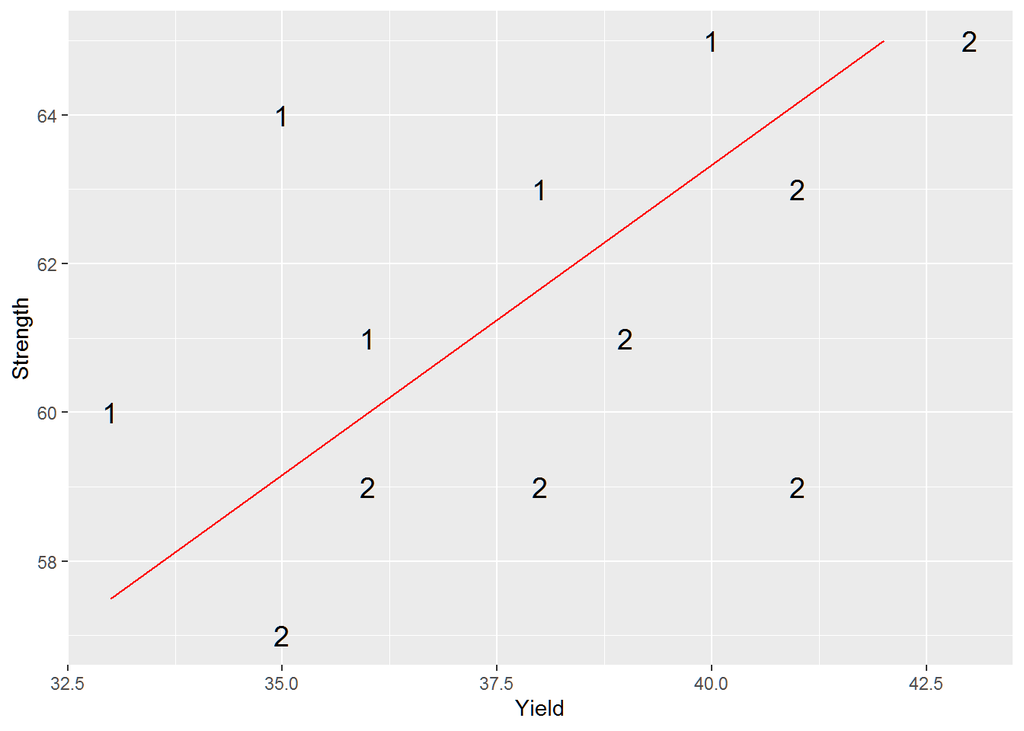

```r
# Plot the data
ggplot(steel, aes(x = Yield, y = Strength)) +
    geom_text(aes(label = Temp), size = 5) +
    geom_segment(aes(
        x = 33,
        y = 57.5,
        xend = 42,
        yend = 65
    ), col = "red")
```

```r
# Bartlett's test for equality of covariance matrices
# same thing as Box's M test in the multivariate setting
bart_test <- boxM(steel[, -1], steel$Temp)
bart_test # fail to reject the null of equal covariances
```

```
##
##  Box's M-test for Homogeneity of Covariance Matrices
##
## data:  steel[, -1]
## Chi-Sq (approx.) = 0.38077, df = 3, p-value = 0.9442
```

```r
# anova.mlm
twosamp_fit <-
    anova(lm(cbind(Yield, Strength) ~ factor(Temp), data = steel), test = "Wilks")
twosamp_fit
```

```
## Analysis of Variance Table
##
##              Df    Wilks approx F num Df den Df    Pr(>F)
## (Intercept)   1 0.001177   3818.1      2      9 6.589e-14 ***
## factor(Temp)  1 0.294883     10.8      2      9  0.004106 **
## Residuals    10
## ---
## Signif. codes:  0 '***' 0.001 '**' 0.01 '*' 0.05 '.' 0.1 ' ' 1
```

```r
# ICSNP package
twosamp_fit2 <-
    HotellingsT2(cbind(steel$Yield, steel$Strength) ~ factor(steel$Temp))
twosamp_fit2
```

```
##
##  Hotelling's two sample T2-test
##
## data:  cbind(steel$Yield, steel$Strength) by factor(steel$Temp)
## T.2 = 10.76, df1 = 2, df2 = 9, p-value = 0.004106
## alternative hypothesis: true location difference is not equal to c(0,0)
```

```r
# reject null. Hence, there is a difference in the means of the bivariate normal distributions
```

## MANOVA

Multivariate Analysis of Variance

One-way MANOVA

Compare treatment means for h different populations

Population 1: $\mathbf{y}_{11}, \mathbf{y}_{12}, \dots, \mathbf{y}_{1n_1} \sim idd N_p (\mathbf{\mu}_1, \mathbf{\Sigma})$

$\vdots$

Population h: $\mathbf{y}_{h1}, \mathbf{y}_{h2}, \dots, \mathbf{y}_{hn_h} \sim idd N_p (\mathbf{\mu}_h, \mathbf{\Sigma})$

**Assumptions**

1. Independent random samples from $h$ different populations
2. Common covariance matrices
3. Each population is multivariate **normal**

Calculate the summary statistics $\mathbf{\bar{y}}_i, \mathbf{S}$ and the pooled estimate of the covariance matrix $\mathbf{S}$

Similar to the univariate one-way ANVOA, we can use the effects model formulation $\mathbf{\mu}_i = \mathbf{\mu} + \mathbf{\tau}_i$, where

- $\mathbf{\mu}_i$ is the population mean for population i
- $\mathbf{\mu}$ is the overall mean effect
- $\mathbf{\tau}_i$ is the treatment effect of the i-th treatment.

For the one-way model: $\mathbf{y}_{ij} = \mu + \tau_i + \epsilon_{ij}$ for $i = 1,..,h; j = 1,..., n_i$ and $\epsilon_{ij} \sim N_p(\mathbf{0, \Sigma})$

However, the above model is over-parameterized (i.e., infinite number of ways to define $\mathbf{\mu}$ and the $\mathbf{\tau}_i$’s such that they add up to $\mu_i$. Thus we can constrain by having

$$\sum_{i=1}^h n_i \tau_i = 0$$

or

$$\mathbf{\tau}_h = 0$$

The observational equivalent of the effects model is

$$\begin{aligned}
\mathbf{y}_{ij} &= \mathbf{\bar{y}} + (\mathbf{\bar{y}}_i -
\mathbf{\bar{y}}) + (\mathbf{y}_{ij} - \mathbf{\bar{y}}_i) \\
&= \text{overall sample mean} + \text{treatement effect} +
\text{residual} \text{ (under univariate ANOVA)}
\end{aligned}$$

After manipulation

$$\sum_{i = 1}^h \sum_{j = 1}^{n_i} (\mathbf{\bar{y}}_{ij} -
\mathbf{\bar{y}})(\mathbf{\bar{y}}_{ij} - \mathbf{\bar{y}})' =
\sum_{i = 1}^h n_i (\mathbf{\bar{y}}_i -
\mathbf{\bar{y}})(\mathbf{\bar{y}}_i - \mathbf{\bar{y}})' +
\sum_{i=1}^h \sum_{j = 1}^{n_i} (\mathbf{\bar{y}}_{ij} -
\mathbf{\bar{y}})(\mathbf{\bar{y}}_{ij} - \mathbf{\bar{y}}_i)'$$

LHS = Total corrected sums of squares and cross products (SSCP) matrix

RHS =

- 1st term = Treatment (or between subjects) sum of squares and cross product matrix (denoted H;B)
- 2nd term = residual (or within subject) SSCP matrix denoted (E;W)

Note:

$$\mathbf{E} = (n_1 - 1)\mathbf{S}_1 + ... + (n_h -1) \mathbf{S}_h =
(n-h) \mathbf{S}$$

MANOVA table

MONOVA table

| Source | SSCP | df |
| --- | --- | --- |
| Treatment | $\mathbf{H}$ | $h -1$ |
| Residual (error) | $\mathbf{E}$ | $\sum_{i= 1}^h n_i - h$ |
| Total Corrected | $\mathbf{H + E}$ | $\sum_{i=1}^h n_i -1$ |

$$H_0: \tau_1 = \tau_2 = \dots = \tau_h = \mathbf{0}$$

We consider the relative “sizes” of $\mathbf{E}$ and $\mathbf{H+E}$

Wilk’s Lambda

Define Wilk’s Lambda

$$\Lambda^* = \frac{|\mathbf{E}|}{|\mathbf{H+E}|}$$

Properties:

1. Wilk’s Lambda is equivalent to the F-statistic in the univariate case
2. The exact distribution of $\Lambda^*$ can be determined for especial cases.
3. For large sample sizes, reject $H_0$ if

$$-(\sum_{i=1}^h n_i - 1 - \frac{p+h}{2}) \log(\Lambda^*) >
\chi^2_{(1-\alpha, p(h-1))}$$

### Testing General Hypotheses

- $h$ different treatments
- with the i-th treatment
- applied to $n_i$ subjects that
- are observed for $p$ repeated measures.

Consider this a $p$ dimensional obs on a random sample from each of $h$ different treatment populations.

$$\mathbf{y}_{ij} = \mathbf{\mu} + \mathbf{\tau}_i +
\mathbf{\epsilon}_{ij}$$

for $i = 1,..,h$ and $j = 1,..,n_i$

Equivalently,

$$\mathbf{Y} = \mathbf{XB} + \mathbf{\epsilon}$$

where $n = \sum_{i = 1}^h n_i$ and with restriction $\mathbf{\tau}_h = 0$

$$\mathbf{Y}_{(n \times p)} =
\left[
\begin{array}
{c}
\mathbf{y}_{11}' \\
\vdots \\
\mathbf{y}_{1n_1}' \\
\vdots \\
\mathbf{y}_{hn_h}'
\end{array}
\right],
\mathbf{B}_{(h \times p)} =
\left[
\begin{array}
{c}
\mathbf{\mu}' \\
\mathbf{\tau}_1' \\
\vdots \\
\mathbf{\tau}_{h-1}'
\end{array}
\right],
\mathbf{\epsilon}_{(n \times p)} =
\left[
\begin{array}
{c}
\epsilon_{11}' \\
\vdots \\
\epsilon_{1n_1}' \\
\vdots \\
\epsilon_{hn_h}'
\end{array}
\right]$$

$$\mathbf{X}_{(n \times h)} =
\left[
\begin{array}
{ccccc}
1 & 1 & 0 & \ldots & 0 \\
\vdots & \vdots & \vdots & & \vdots \\
1 & 1 & 0 & \ldots & 0 \\
\vdots & \vdots & \vdots & \ldots & \vdots \\
1 & 0 & 0 & \ldots & 0 \\
\vdots & \vdots & \vdots & & \vdots \\
1 & 0 & 0 & \ldots & 0
\end{array}
\right]$$

Estimation

$$\mathbf{\hat{B}} = (\mathbf{X'X})^{-1} \mathbf{X'Y}$$

Rows of $\mathbf{Y}$ are independent (i.e., $var(\mathbf{Y}) = \mathbf{I}_n \otimes \mathbf{\Sigma}$ , an $np \times np$ matrix, where $\otimes$ is the Kronecker product).

$$H_0: \mathbf{LBM} = 0 \\
H_a: \mathbf{LBM} \neq 0$$

where

- $\mathbf{L}$ is a $g \times h$ matrix of full row rank ($g \le h$) = comparisons across groups
- $\mathbf{M}$ is a $p \times u$ matrix of full column rank ($u \le p$) = comparisons across traits

The general treatment corrected sums of squares and cross product is

$$\mathbf{H} =
\mathbf{M'Y'X(X'X)^{-1}L'[L(X'X)^{-1}L']^{-1}L(X'X)^{-1}X'YM}$$

or for the null hypothesis $H_0: \mathbf{LBM} = \mathbf{D}$

$$\mathbf{H} = (\mathbf{\hat{LBM}} -
\mathbf{D})'[\mathbf{X(X'X)^{-1}L}]^{-1}(\mathbf{\hat{LBM}} -
\mathbf{D})$$

The general matrix of residual sums of squares and cross product

$$\mathbf{E} = \mathbf{M'Y'[I-X(X'X)^{-1}X']YM} =
\mathbf{M'[Y'Y - \hat{B}'(X'X)^{-1}\hat{B}]M}$$

We can compute the following statistic eigenvalues of $\mathbf{HE}^{-1}$

- Wilk’s Criterion: $\Lambda^* = \frac{|\mathbf{E}|}{|\mathbf{H} + \mathbf{E}|}$ . The df depend on the rank of $\mathbf{L}, \mathbf{M}, \mathbf{X}$
- Lawley-Hotelling Trace: $U = tr(\mathbf{HE}^{-1})$
- Pillai Trace: $V = tr(\mathbf{H}(\mathbf{H}+ \mathbf{E}^{-1})$
- Roy’s Maximum Root: largest eigenvalue of $\mathbf{HE}^{-1}$

If $H_0$ is true and n is large, $-(n-1- \frac{p+h}{2})\ln \Lambda^* \sim \chi^2_{p(h-1)}$. Some special values of p and h can give exact F-dist under $H_0$